# M12992211_Assignment3_code(ipynb)

## Importing basic libraries for plots and matrix calculations

```python
import numpy as np
import pandas as pd
import random
import os
import math
import pickle
import matplotlib.pyplot as plt
```

## Reading both feature and label text files and saving into dataframe and viewing first five records

```python
data_img = pd.read_csv('MNISTnumImages5000.txt',sep="\t", header=None)
```

```python
data_lbl = pd.read_csv('MNISTnumLabels5000.txt', sep="\t", header=None)
```

```python
data_img.head()
```

|  | 0 | 1 | 2 | 3 | 4 | 5 | 6 | 7 | 8 | 9 | ... | 774 | 775 | 776 | 777 | 778 | 779 | 780 | 781 | 782 | 783 |
| --- | --- | --- | --- | --- | --- | --- | --- | --- | --- | --- | --- | --- | --- | --- | --- | --- | --- | --- | --- | --- | --- |
| 0 | 0 | 0 | 0 | 0 | 0 | 0 | 0 | 0 | 0 | 0.0 | ... | 0.0 | 0.0 | 0 | 0 | 0 | 0 | 0 | 0 | 0 | 0 |
| 1 | 0 | 0 | 0 | 0 | 0 | 0 | 0 | 0 | 0 | 0.0 | ... | 0.0 | 0.0 | 0 | 0 | 0 | 0 | 0 | 0 | 0 | 0 |
| 2 | 0 | 0 | 0 | 0 | 0 | 0 | 0 | 0 | 0 | 0.0 | ... | 0.0 | 0.0 | 0 | 0 | 0 | 0 | 0 | 0 | 0 | 0 |
| 3 | 0 | 0 | 0 | 0 | 0 | 0 | 0 | 0 | 0 | 0.0 | ... | 0.0 | 0.0 | 0 | 0 | 0 | 0 | 0 | 0 | 0 | 0 |
| 4 | 0 | 0 | 0 | 0 | 0 | 0 | 0 | 0 | 0 | 0.0 | ... | 0.0 | 0.0 | 0 | 0 | 0 | 0 | 0 | 0 | 0 | 0 |

5 rows × 784 columns

```python
data_lbl.head()
```

|  | 0 |
| --- | --- |
| 0 | 7 |
| 1 | 2 |
| 2 | 1 |
| 3 | 0 |
| 4 | 4 |

## Distribution of records digit wise

```python
data_lbl.iloc[:,0].value_counts()
```

```
1    571
2    530
9    520
7    512
3    500
4    500
8    489
6    462
0    460
5    456
Name: 0, dtype: int64
```

## Function to change target to 1,0 representation

```python
def bin_encode(target):
    arr_target = np.zeros((10, 1))
    a=[]
    for i in range(10):
        if i==target:
            a.append([1.])
        else:
            a.append([0.])
    arr_target=np.array(a)
    return arr_target
```

## Activations functions and their derivative functions

```python
def act_sig(u):
    v = 1.0 / (1.0 + np.exp(-u))
    return v

def act_sig_deri(u):
    v= act_sig(u) * (1 - act_sig(u))
    return v

def act_relu(u):
    v=np.maximum(u,0)
    return v

def act_relu_deri(u):
    u[u<=0]=0
    u[u>0]=1
    return u

def act_tanh(u,a,b):
    v = a * np.tanh(b * u)
    return v

def act_tanh_deri(u,a,b):
    v= (b/a) * ((a*a) - (u * u))
    return v

def get_act(act_fun,u):
    if act_fun=="sigmoid":
        return act_sig(u)
    elif act_fun=="relu":
        return act_relu(u)
    elif act_fun=="tanh":
        a=1.7159
        b=2/3
        return act_tanh(u,a,b)
    else:
        raise ValueError('Activation function not found')

def get_act_derv(act_fun,u):
    if act_fun=="sigmoid":
        return act_sig_deri(u)
    elif act_fun=="relu":
        return act_relu_deri(u)
    elif act_fun=="tanh":
        a=1.7159
        b=2/3
        return act_tanh_deri(u,a,b)
    else:
        raise ValueError('Activation function not found')
```

## Multi layer Feed forward network implementation with following parameters as inputs :

layers_list :- list containing input neurons , hidden layers neurons , output layer neurons in same order. activations :- list containing corresponding activation functions (sigmoid, relu ,tanh) first element of list can be anything as inputs will be first activations and so no need of activation function. lr :- learning rate momentum :- momentum iters :- epochs bat_size :- batch size for Stochaistic Gradient Descent auto :- flag to run second ques as it involves calculating cost function which is not needed for ques 1

```python
class Model(object):

    def __init__(self, layer_list=list(),act_list=list(), lr=1.0,momentum=0.1,iters=10, bat_size=16, auto=False):

        self.eta = lr
        self.momentum = momentum
        self.iters = iters
        self.bat_size = bat_size
        self.auto=auto
        self.layer_list = layer_list
        self.layers_len = len(layer_list)
        self.act_list=act_list
        self.act_len = len(act_list)
        if self.layers_len != self.act_len:
            raise ValueError('Activations and Layers size should match')

        self.W=[]
        self.W.append(np.array([0]))
        for i in range(1,len(layer_list)):
            a=math.sqrt(6/layer_list[i-1])
            tmp=np.zeros((layer_list[i],layer_list[i-1]))
            for j in range(layer_list[i]):
                tmp[j]=np.random.uniform(-a, a, layer_list[i-1])
            self.W.append(tmp)

        self.B = [np.zeros((i,1)) for i in layer_list]
        self.S = [np.zeros((i,1)) for i in layer_list]
        self.A = [np.zeros((i,1)) for i in layer_list]

        if self.auto:
            self.store("auto-intial-"+str(self.layer_list[1])+".pkl")
        else:
            self.store("model-intial-"+str(self.layer_list[1])+".pkl")



    def train(self, dt_train, dt_val, dt_test, auto):

        flag=0
        thr=[]
        vhr=[]
        tehr=[]

        tc=[]
        vc=[]
        tec=[]

        if auto:
            train_cost = (self.getError(dt_train))
            val_cost = (self.getError(dt_val))
            test_cost =(self.getError(dt_test))
            tc.append(train_cost)
            vc.append(val_cost)
            tec.append(test_cost)
            print("For epoch {0}, validating error {1} , training error {2} , testing error {3}.".format(0,val_cost,train_cost,test_cost))
        else:
            train_hit_rate = (self.validateTrain(dt_train)) / (len(dt_train))
            val_hit_rate = (self.validate(dt_val)) / (len(dt_val))
            test_hit_rate =(self.validate(dt_test)) / (len(dt_test))
            thr.append(train_hit_rate)
            vhr.append(val_hit_rate)
            tehr.append(test_hit_rate)
            print("For epoch {0}, validating hit rate {1} , training hit rate {2} , testing hit rate {3}.".format(0,val_hit_rate,train_hit_rate,test_hit_rate))


        for itr in range(self.iters):
            random.shuffle(dt_train)
            train_subsets=[]
            for i in range(0, len(dt_train), self.bat_size):
                train_subsets.append(dt_train[i:i + self.bat_size])
            for dt_train_batch in train_subsets:
                delta_b = [np.zeros(b.shape) for b in self.B]
                main_delta_b= [np.zeros(b.shape) for b in self.B]

                delta_w = [np.zeros(w.shape) for w in self.W]
                main_delta_w= [np.zeros(w.shape) for w in self.W]
                for features, targets in dt_train_batch:
                    self.FP(features)
                    tmp_delta_b, tmp_delta_w = self.BP(targets)
                    delta_b = [db + tdb  for db, tdb in zip(delta_b, tmp_delta_b)]
                    delta_w = [dw + tdw  for dw, tdw in zip(delta_w, tmp_delta_w)]

                prev_delta_b = main_delta_b
                prev_delta_w = main_delta_w
                main_delta_w = [(-(self.eta / self.bat_size )* del_w) + (self.momentum * p_d_w) for del_w,p_d_w in zip (delta_w,prev_delta_w)]
                main_delta_b = [(-(self.eta / self.bat_size )* del_b) + (self.momentum * p_d_b) for del_b,p_d_b in zip (delta_b,prev_delta_b)]

                self.updateWeights(main_delta_w, main_delta_b)
                #self.store("model-"+str(self.eta)+"-"+str(self.momentum)+str(self.act_list[1])+str(itr+1)+".pkl")

            if not (itr+1) % 10:
                if auto:
                    train_cost = (self.getError(dt_train))
                    val_cost = (self.getError(dt_val))
                    test_cost =(self.getError(dt_test))
                    tc.append(train_cost)
                    vc.append(val_cost)
                    tec.append(test_cost)
                    print("For epoch {0}, validating error {1} , training error {2} , testing error {3}.".format(itr + 1,val_cost,train_cost,test_cost))
                    if len(vc)>3:
                        if ((vc[-1]>vc[-2] and vc[-1] > vc[-3] and vc[-1] > vc[-4]) or (vc[-1] ==vc[-2] and vc[-1] ==vc[-2] and vc[-1] ==vc[-3])):
                            flag=1
                else:
                    train_hit_rate = (self.validateTrain(dt_train)) / (len(dt_train))
                    val_hit_rate = (self.validate(dt_val)) / (len(dt_val))
                    test_hit_rate =(self.validate(dt_test)) / (len(dt_test))
                    thr.append(train_hit_rate)
                    vhr.append(val_hit_rate)
                    tehr.append(test_hit_rate)
                    print("For epoch {0}, validating hit rate {1} , training hit rate {2} , testing hit rate {3}.".format(itr + 1,val_hit_rate,train_hit_rate,test_hit_rate))
                    if len(vhr)>3:
                        if ((vhr[-1]<vhr[-2] and vhr[-1] < vhr[-3] and vhr[-1] < vhr[-4]) or (vhr[-1] ==vhr[-2] and vhr[-1] ==vhr[-2] and vhr[-1] ==vhr[-3])):
                            flag=1
            #comment below code to run without stopping rule
            if flag==1:
                if auto:
                    self.store("auto-"+str(self.eta)+"-"+str(self.momentum)+str(self.act_list[-2])+'-'+str(self.act_list[-1])+str(itr+1)+".pkl")
                else:
                    self.store("model-"+str(self.eta)+"-"+str(self.momentum)+str(self.act_list[-2])+'-'+str(self.act_list[-1])+str(itr+1)+".pkl")
                break

            if not (itr+1) % 30:
                if auto:
                    self.store("auto-"+str(self.eta)+"-"+str(self.momentum)+str(self.act_list[-2])+'-'+str(self.act_list[-1])+str(itr+1)+".pkl")
                else:
                    self.store("model-"+str(self.eta)+"-"+str(self.momentum)+str(self.act_list[-2])+'-'+str(self.act_list[-1])+str(itr+1)+".pkl")

        return {'thr':thr,'vhr':vhr,'tehr':tehr,'vc':vc,'tc':tc,'tec':tec}

    def getError(self,dt):
        mainCost=0
        for feat, targ in dt:
            pred=self.test_auto(feat)
            err=targ-pred
            sqEr=err  * err
            tmpCost=(1/2) * np.sum(sqEr)
            mainCost=mainCost+tmpCost
        return mainCost

    def updateWeights(self, main_delta_w, main_delta_b):

        self.W = [w + delw for w, delw  in zip(self.W, main_delta_w)]
        self.B = [b + delb for b, delb in zip(self.B, main_delta_b)]

    def validate(self, dt_val):
        corr_points=0
        for feat, targ in dt_val:
            if self.test(feat) == targ:
                corr_points=corr_points+1
        return corr_points

    def validateTrain(self, dt_val):
        ft = []
        lb=  []
        for i, j in dt_val:
            ft.append(i)
            lb.append(np.argmax(j))
        dt=list(zip(ft,lb))
        corr_points=0
        for feat, targ in dt:
            if self.test(feat) == targ:
                corr_points=corr_points+1
        return corr_points

    def test(self, features):
        self.FP(features)
        return np.argmax(self.A[-1])

    def test_auto(self, features):
        self.FP(features)
        return self.A[-1]

    def FP(self, features):
        self.A[0] = features
        for i in range(1, self.layers_len):
            self.S[i] = (self.W[i].dot(self.A[i - 1]) + self.B[i])
            self.A[i] = get_act(self.act_list[i],self.S[i])

    def BP(self, target):
        delta_b = [np.zeros(b.shape) for b in self.B]
        delta_w = [np.zeros(w.shape) for w in self.W]
        #delta for output layer
        tmp_del = (self.A[-1]-target) * get_act_derv(self.act_list[-1],self.S[-1])
        delta_b[-1] = tmp_del
        delta_w[-1] = tmp_del.dot(self.A[-2].transpose())
        #delta for hidden layes
        for l in range(self.layers_len - 2, 0, -1):
            tmp_del = np.multiply(self.W[l + 1].transpose().dot(tmp_del),get_act_derv(self.act_list[l],self.S[l]))
            delta_b[l] = tmp_del
            delta_w[l] = tmp_del.dot(self.A[l - 1].transpose())
        return delta_b, delta_w

    def store(self, file='weights.pkl'):

        lr=self.eta
        mm=self.momentum
        iters=self.iters
        bs=self.bat_size

        ll=self.layer_list
        al=self.act_list

        W=self.W
        B=self.B

        dict={'lr':lr,'mm':mm,'iters':iters,'bs':bs,'ll':ll,'al':al,'W':W,'B':B}
        with open(os.path.join(os.curdir, file), 'wb') as f:
            pickle.dump(dict, f)

    def load(self, epoch, lr,mm, file='weights.pkl', actFun_list=['NR','sigmoid','sigmoid']):

        with open(os.path.join(os.curdir, file),'rb') as f:
            objb= pickle.load(f)
        self.eta=lr
        self.momentum=mm
        self.iters = epoch
        self.bat_size=int(objb['bs'])
        self.act_list=actFun_list
        self.act_len = len(self.act_list)
        self.W = list(objb['W'])
        self.B = list(objb['B'])
        self.layer_list = [b.shape[0] for b in self.B]
        self.layers_len = len(self.layer_list)
        self.S = [np.zeros(b.shape) for b in self.B]
        self.A = [np.zeros(b.shape) for b in self.B]
```

## Splitting Data into train and test and viewing corresponding digit distribution

```python
from sklearn.model_selection import train_test_split
X_train, X_test, Y_train, Y_test = train_test_split(data_img, data_lbl, test_size=0.2, random_state=0 , stratify=data_lbl)
```

```python
Y_train.iloc[:,0].value_counts()
```

```
1    457
2    424
9    416
7    409
3    400
4    400
8    391
6    370
0    368
5    365
Name: 0, dtype: int64
```

```python
Y_test.iloc[:,0].value_counts()
```

```
1    114
2    106
9    104
7    103
4    100
3    100
8     98
6     92
0     92
5     91
Name: 0, dtype: int64
```

## splitting train into train_new and validation dataset with 3500 points as train_new and 500 as validation set

```python
X_train_new, X_valid, Y_train_new, Y_valid = train_test_split(X_train, Y_train, test_size=0.125, random_state=0 , stratify=Y_train)
```

```python
Y_train_new.iloc[:,0].value_counts()
```

```
1    400
2    371
9    364
7    358
3    350
4    350
8    342
6    324
0    322
5    319
Name: 0, dtype: int64
```

```python
Y_valid.iloc[:,0].value_counts()
```

```
1    57
2    53
9    52
7    51
4    50
3    50
8    49
6    46
5    46
0    46
Name: 0, dtype: int64
```

## Changing input and output into 2d array

```python
arr_x_train = [np.reshape(X_train_new.iloc[i,:].tolist(), (len(X_train_new.columns), 1)) for i in range(len(X_train_new))]
arr_y_train = [bin_encode(y) for y in Y_train_new.iloc[:,0].tolist()]
data_train = list(zip(arr_x_train, arr_y_train))
```

```python
arr_x_val = [np.reshape(X_valid.iloc[i,:].tolist(), (len(X_valid.columns), 1)) for i in range(len(X_valid))]
arr_y_val = Y_valid.iloc[:,0].tolist()
data_val = list(zip(arr_x_val, arr_y_val))
```

```python
arr_x_test = [np.reshape(X_test.iloc[i,:].tolist(), (len(X_test.columns), 1)) for i in range(len(X_test))]
arr_y_test = Y_test.iloc[:,0].tolist()
data_test = list(zip(arr_x_test, arr_y_test))
```

## Preparing data for auto encoder where target variables will be same as input

```python
arr_x_train_auto = [np.reshape(X_train_new.iloc[i,:].tolist(), (len(X_train_new.columns), 1)) for i in range(len(X_train_new))]
data_train_auto = list(zip(arr_x_train_auto, arr_x_train_auto))
```

```python
arr_x_val_auto = [np.reshape(X_valid.iloc[i,:].tolist(), (len(X_valid.columns), 1)) for i in range(len(X_valid))]
data_val_auto = list(zip(arr_x_val_auto, arr_x_val_auto))
```

```python
arr_x_test_auto = [np.reshape(X_test.iloc[i,:].tolist(), (len(X_test.columns), 1)) for i in range(len(X_test))]
data_test_auto = list(zip(arr_x_test_auto, arr_x_test_auto))
```

## Different Running Auto Encoder with specifications as given in code

```python
# After balanced split

#initialize layer sizes as list
layers = [784,150,784]
act_funcs=['NR','sigmoid','sigmoid']
momentum = 0.3
lr = 0.1
itrs = 500
batch_size = 32

nn = Model(layers,act_funcs, lr, momentum, itrs, batch_size,True)

#training neural network
Run1=nn.train(data_train_auto, data_val_auto, data_test_auto,True)
```

```
For epoch 0, validating error 51325.82429781404 , training error 359197.3736787727 , testing error 102519.4327362917.
For epoch 10, validating error 4292.107003988454 , training error 30104.69710986043 , testing error 8846.288135007018.
For epoch 20, validating error 2924.673999828148 , training error 20160.311328598633 , testing error 6048.609818410179.
For epoch 30, validating error 2318.7882008104257 , training error 15709.372171455596 , testing error 4807.4475565808825.
For epoch 40, validating error 1976.3810244421497 , training error 13156.436525878971 , testing error 4105.529202948762.
For epoch 50, validating error 1750.5367860008744 , training error 11458.41741643627 , testing error 3646.780953636084.
For epoch 60, validating error 1591.0152336688834 , training error 10232.986150270253 , testing error 3320.6218745555498.
For epoch 70, validating error 1472.3639318873493 , training error 9300.958378251495 , testing error 3076.3247174160847.
For epoch 80, validating error 1377.3759431166968 , training error 8554.423096778974 , testing error 2880.0235298733032.
For epoch 90, validating error 1298.9079967149305 , training error 7933.594213999812 , testing error 2718.4324519324714.
For epoch 100, validating error 1235.3130615499022 , training error 7418.648112115109 , testing error 2584.3959107417872.
For epoch 110, validating error 1179.512615183616 , training error 6974.9734556555795 , testing error 2469.7307914447065.
For epoch 120, validating error 1133.4526896049367 , training error 6596.654324193695 , testing error 2373.0169938303534.
For epoch 130, validating error 1092.426798209005 , training error 6266.481221735766 , testing error 2287.892844553595.
For epoch 140, validating error 1057.5728893772305 , training error 5976.355923170126 , testing error 2212.5002156970745.
For epoch 150, validating error 1026.239479406942 , training error 5715.102246824426 , testing error 2147.3471095987406.
For epoch 160, validating error 998.2085203489355 , training error 5482.808393054022 , testing error 2088.3557124480103.
For epoch 170, validating error 972.8086990501571 , training error 5274.2454621552315 , testing error 2035.323479900538.
For epoch 180, validating error 949.5270593731328 , training error 5086.991681677505 , testing error 1984.8531195871115.
For epoch 190, validating error 928.428692712198 , training error 4910.071518022358 , testing error 1942.2830851083563.
For epoch 200, validating error 909.7336747178592 , training error 4752.641937263474 , testing error 1901.940401795404.
For epoch 210, validating error 892.7684692713048 , training error 4605.003262284017 , testing error 1865.8433238788266.
For epoch 220, validating error 875.8315569280236 , training error 4470.435031205055 , testing error 1829.1952823260751.
For epoch 230, validating error 861.2130590786641 , training error 4343.3954821785055 , testing error 1798.422461255644.
For epoch 240, validating error 847.6454398496044 , training error 4226.316232144477 , testing error 1767.0843621023168.
For epoch 250, validating error 835.6542731232481 , training error 4118.959016613485 , testing error 1743.0282871316274.
For epoch 260, validating error 823.12289528068 , training error 4014.5716110254393 , testing error 1716.7149088844978.
For epoch 270, validating error 810.9542270790834 , training error 3918.3167877035194 , testing error 1691.188894319246.
For epoch 280, validating error 800.5858939574665 , training error 3828.9189029752633 , testing error 1668.1604090227531.
For epoch 290, validating error 791.2363992491836 , training error 3743.312856722142 , testing error 1648.869096560264.
For epoch 300, validating error 780.193279211427 , training error 3666.347696351443 , testing error 1624.920510441495.
For epoch 310, validating error 771.2041324462991 , training error 3588.868537610569 , testing error 1605.0571740446912.
For epoch 320, validating error 763.2033811473269 , training error 3516.6822169818806 , testing error 1588.7888316173676.
For epoch 330, validating error 756.3575771104688 , training error 3449.653855151984 , testing error 1573.9765375006607.
```

[output cut: 17 more lines]

## Running code from intial random weights chosen based on Xavier rule and using different parameter values

```python
nn.load(500,0.1,0.3,'auto-intial-150.pkl',['NR','relu','relu'])
Run2=nn.train(data_train_auto, data_val_auto, data_test_auto,True)
```

```
For epoch 0, validating error 35469.01943892328 , training error 249359.58646060573 , testing error 71804.92002004193.
For epoch 10, validating error 11419.850017477436 , training error 80944.23397920502 , testing error 23297.16077981835.
For epoch 20, validating error 11489.45544188611 , training error 81442.04073897073 , testing error 23442.624142327502.
For epoch 30, validating error 11380.452085022198 , training error 80549.48126668809 , testing error 23211.564546522608.
For epoch 40, validating error 11370.703045930259 , training error 80385.94467432846 , testing error 23146.908015194003.
For epoch 50, validating error 10794.588066917397 , training error 75727.94889742599 , testing error 21864.52218962759.
For epoch 60, validating error 11389.794628006799 , training error 80556.90475741321 , testing error 23206.72911829923.
For epoch 70, validating error 11383.940843864859 , training error 80486.75680889298 , testing error 23193.095779058527.
For epoch 80, validating error 12451.188300540642 , training error 87837.0285876627 , testing error 25231.971373374836.
For epoch 90, validating error 11386.015450915738 , training error 80601.07447168251 , testing error 23211.2894720683.
For epoch 100, validating error 10865.63842780746 , training error 76085.31507227836 , testing error 22054.826232102114.
For epoch 110, validating error 11416.700125485522 , training error 80841.62021378113 , testing error 23308.530959396187.
For epoch 120, validating error 11412.624045929535 , training error 80664.01996493865 , testing error 23226.81790179619.
For epoch 130, validating error 11388.11144899004 , training error 80459.25318698962 , testing error 23166.225675776906.
For epoch 140, validating error 11406.481985735705 , training error 80616.40305635896 , testing error 23244.641092271697.
For epoch 150, validating error 11378.069001104228 , training error 80568.43482593489 , testing error 23216.349225573016.
For epoch 160, validating error 11464.522159670621 , training error 81187.14975242705 , testing error 23406.412899291234.
For epoch 170, validating error 11369.246386319257 , training error 80331.9823709341 , testing error 23142.91619248213.
For epoch 180, validating error 11377.147003701695 , training error 80552.55886719628 , testing error 23213.003810778682.
For epoch 190, validating error 12041.19821701597 , training error 85280.47445466963 , testing error 24491.546450110432.
For epoch 200, validating error 11417.194669864433 , training error 81012.53491116558 , testing error 23334.215675557014.
For epoch 210, validating error 11409.827239140353 , training error 80447.35341106134 , testing error 23178.04048078865.
For epoch 220, validating error 11418.670187912254 , training error 80812.50458200125 , testing error 23294.400121595823.
For epoch 230, validating error 11422.681970416737 , training error 80753.94977495635 , testing error 23260.6481232126.
For epoch 240, validating error 11332.997882942771 , training error 80225.22038681338 , testing error 23134.27521867952.
For epoch 250, validating error 11363.587778585119 , training error 80323.52882442145 , testing error 23143.92574536956.
For epoch 260, validating error 11677.67935456142 , training error 82359.36886099144 , testing error 23680.70697981557.
For epoch 270, validating error 11470.101673072964 , training error 81174.83629002022 , testing error 23401.693308789738.
For epoch 280, validating error 11418.45218463873 , training error 80937.61278514445 , testing error 23343.246629259345.
For epoch 290, validating error 11448.196747657219 , training error 80978.84087812075 , testing error 23311.620005141813.
For epoch 300, validating error 11432.507549353339 , training error 80959.06300253076 , testing error 23335.71296040101.
For epoch 310, validating error 11456.130502121907 , training error 80954.96340909183 , testing error 23312.342908157603.
For epoch 320, validating error 11345.578085676758 , training error 80325.39528956843 , testing error 23140.87763664628.
For epoch 330, validating error 11662.739517712036 , training error 82465.41392854575 , testing error 23748.510229982767.
```

[output cut: 17 more lines]

```python
nn.load(500,0.1,0.3,'auto-intial-150.pkl',['NR','relu','sigmoid'])
Run3=nn.train(data_train_auto, data_val_auto, data_test_auto,True)
```

```
For epoch 0, validating error 48646.67516466604 , training error 340361.8113108364 , testing error 97200.50603115957.
For epoch 10, validating error 1537.6542786458203 , training error 10019.615005014959 , testing error 3217.6605532980534.
For epoch 20, validating error 1018.493853315582 , training error 6232.385428394272 , testing error 2136.529013265781.
For epoch 30, validating error 846.9096690644935 , training error 4904.420771478821 , testing error 1771.01692915884.
For epoch 40, validating error 766.483424728851 , training error 4265.033228225252 , testing error 1605.5295303051385.
For epoch 50, validating error 706.4698230442832 , training error 3804.4962165409615 , testing error 1490.6766951435918.
For epoch 60, validating error 672.2618611327798 , training error 3507.9675472084086 , testing error 1419.261225689292.
For epoch 70, validating error 642.180107275415 , training error 3272.169602350118 , testing error 1357.4474847194008.
For epoch 80, validating error 618.361983297864 , training error 3071.9126582675244 , testing error 1306.6134541256354.
For epoch 90, validating error 602.6540492946343 , training error 2930.017790468592 , testing error 1274.4111722873445.
For epoch 100, validating error 591.8412426337577 , training error 2812.558970424982 , testing error 1252.536521166639.
For epoch 110, validating error 579.0041901696273 , training error 2686.5935375108497 , testing error 1220.4530767187377.
For epoch 120, validating error 568.3321454628624 , training error 2584.0089849312776 , testing error 1196.6475561894933.
For epoch 130, validating error 561.1681466869118 , training error 2538.439654857293 , testing error 1187.6380308052292.
For epoch 140, validating error 553.3615111057861 , training error 2439.3667692143686 , testing error 1162.3669338615205.
For epoch 150, validating error 546.787767758475 , training error 2365.6483962052444 , testing error 1148.4636523981321.
For epoch 160, validating error 539.4313275316442 , training error 2296.3027333407667 , testing error 1134.293472307617.
For epoch 170, validating error 537.9300493108481 , training error 2257.3894827504996 , testing error 1124.6642674162279.
For epoch 180, validating error 537.3937693562872 , training error 2241.4437684280215 , testing error 1123.8057247464612.
For epoch 190, validating error 534.4903121168913 , training error 2204.7398360184006 , testing error 1121.9925028668513.
For epoch 200, validating error 525.72375714535 , training error 2129.3435149925263 , testing error 1103.0851809332444.
For epoch 210, validating error 523.7603473588289 , training error 2079.271966389601 , testing error 1092.9708548010008.
For epoch 220, validating error 519.2181393449272 , training error 2042.839628590822 , testing error 1087.6965608718947.
For epoch 230, validating error 518.2695370773291 , training error 2033.6729942932418 , testing error 1085.8235550176228.
For epoch 240, validating error 517.3052735029315 , training error 1996.8090867075723 , testing error 1082.9618805077744.
For epoch 250, validating error 515.7761457085038 , training error 1970.6233227979594 , testing error 1081.3171644331787.
For epoch 260, validating error 510.18677792462086 , training error 1916.6950338741833 , testing error 1066.0968398732916.
For epoch 270, validating error 508.7942073202094 , training error 1912.0017724115748 , testing error 1069.2498067462625.
For epoch 280, validating error 509.4859684390853 , training error 1891.5481511069925 , testing error 1070.5984634758022.
For epoch 290, validating error 507.1299816083549 , training error 1859.6323352316901 , testing error 1062.4262337724947.
For epoch 300, validating error 508.67920692076893 , training error 1863.4216368390803 , testing error 1067.954538755256.
For epoch 310, validating error 507.7809155313042 , training error 1845.1756369634757 , testing error 1064.9581253922493.
For epoch 320, validating error 506.0429084308494 , training error 1824.6180185980036 , testing error 1061.570239321195.
For epoch 330, validating error 504.32133217979424 , training error 1809.5483258646918 , testing error 1057.7801788755955.
```

[output cut: 17 more lines]

```python
nn.load(500,0.1,0.7,'auto-intial-150.pkl',['NR','sigmoid','sigmoid'])
Run4=nn.train(data_train_auto, data_val_auto, data_test_auto,True)
```

```
For epoch 0, validating error 51325.82429781404 , training error 359197.37367877323 , testing error 102519.4327362917.
For epoch 10, validating error 4288.708346895935 , training error 30108.900344037844 , testing error 8848.144510778255.
For epoch 20, validating error 2923.8642229013108 , training error 20168.711540099455 , testing error 6048.010056735223.
For epoch 30, validating error 2318.680754989711 , training error 15715.404788054007 , testing error 4811.582983870508.
For epoch 40, validating error 1975.7193680322814 , training error 13154.677983191186 , testing error 4107.401673722177.
For epoch 50, validating error 1750.9360987085113 , training error 11455.745895717311 , testing error 3647.6944111421158.
For epoch 60, validating error 1590.3468513218143 , training error 10228.608498785994 , testing error 3318.98166266461.
For epoch 70, validating error 1470.610352004956 , training error 9297.175292566426 , testing error 3073.128086822111.
For epoch 80, validating error 1375.3562172496577 , training error 8549.350540436275 , testing error 2877.021433348702.
For epoch 90, validating error 1297.2007586890206 , training error 7928.664444439067 , testing error 2714.0569073920697.
For epoch 100, validating error 1234.1225247145283 , training error 7416.108358603897 , testing error 2583.196049474275.
For epoch 110, validating error 1179.430559011089 , training error 6976.074763980528 , testing error 2470.903729793474.
For epoch 120, validating error 1131.5983896741357 , training error 6595.158461163329 , testing error 2369.8881501537526.
For epoch 130, validating error 1092.9021086072992 , training error 6265.051461081243 , testing error 2290.3469969061716.
For epoch 140, validating error 1057.063903132924 , training error 5971.82676500334 , testing error 2214.879316565042.
For epoch 150, validating error 1026.1639439717696 , training error 5712.937920550785 , testing error 2148.560326150035.
For epoch 160, validating error 996.8707667388924 , training error 5480.000292632384 , testing error 2086.3394202076147.
For epoch 170, validating error 971.8735717875736 , training error 5271.115727127401 , testing error 2033.5336581810639.
For epoch 180, validating error 948.9830056029349 , training error 5079.987261853593 , testing error 1984.7956130744747.
For epoch 190, validating error 927.9992967590327 , training error 4908.152144487422 , testing error 1942.1529176682564.
For epoch 200, validating error 909.2198174091501 , training error 4747.712061648834 , testing error 1899.7459883455906.
For epoch 210, validating error 891.2605309661981 , training error 4602.000216249504 , testing error 1863.1099467347372.
For epoch 220, validating error 876.3428304041216 , training error 4467.38487076695 , testing error 1830.9133014991498.
For epoch 230, validating error 860.7986791571457 , training error 4340.77373810884 , testing error 1798.784039888715.
For epoch 240, validating error 846.5566078013482 , training error 4222.12705239225 , testing error 1767.8265092575177.
For epoch 250, validating error 833.0696084255136 , training error 4114.053786570684 , testing error 1738.9307481235132.
For epoch 260, validating error 820.973912853435 , training error 4013.7921542305553 , testing error 1711.995129336948.
For epoch 270, validating error 809.9485041619322 , training error 3915.1018884101254 , testing error 1690.4647738235378.
For epoch 280, validating error 799.4282874823949 , training error 3826.922980286213 , testing error 1666.4302219206654.
For epoch 290, validating error 789.1435718972969 , training error 3740.285067901753 , testing error 1645.0276300320886.
For epoch 300, validating error 780.2392872536017 , training error 3663.26714709721 , testing error 1627.156375307482.
For epoch 310, validating error 772.1911924639519 , training error 3585.397964697618 , testing error 1608.5958763199928.
For epoch 320, validating error 762.7395683860307 , training error 3516.2994199746804 , testing error 1588.870101298815.
For epoch 330, validating error 754.6035842456703 , training error 3445.721868082715 , testing error 1571.0955273764407.
```

[output cut: 17 more lines]

```python
nn.load(500,0.1,0.7,'auto-intial-150.pkl',['NR','relu','relu'])
Run5=nn.train(data_train_auto, data_val_auto, data_test_auto,True)
```

```
For epoch 0, validating error 35469.01943892328 , training error 249359.58646060672 , testing error 71804.92002004193.
For epoch 10, validating error 11442.63637278893 , training error 81506.09091558012 , testing error 23511.07285656681.
For epoch 20, validating error 11497.297260817815 , training error 81590.74693108202 , testing error 23520.636735269403.
For epoch 30, validating error 11484.271308471087 , training error 81482.26108749006 , testing error 23438.332694178844.
For epoch 40, validating error 10750.332233111163 , training error 75612.20711687442 , testing error 21872.257894038816.
For epoch 50, validating error 11798.516008275777 , training error 83193.88789520568 , testing error 23913.70089130974.
For epoch 60, validating error 11403.07548563618 , training error 80915.86585356461 , testing error 23310.916721748607.
For epoch 70, validating error 11462.515985276197 , training error 81111.67672013621 , testing error 23358.94021547687.
For epoch 80, validating error 11438.902730482281 , training error 80819.20618196517 , testing error 23282.388391063865.
For epoch 90, validating error 11403.100569231021 , training error 80730.68299407684 , testing error 23248.822654770353.
For epoch 100, validating error 11463.928780658796 , training error 81200.3584736152 , testing error 23410.598476704807.
For epoch 110, validating error 11495.375700563254 , training error 81472.06796534728 , testing error 23480.66366259979.
For epoch 120, validating error 11471.952838487228 , training error 81079.21993896796 , testing error 23352.247452340594.
For epoch 130, validating error 11416.280777244361 , training error 80809.26815618949 , testing error 23284.853592573283.
For epoch 140, validating error 11436.464454572839 , training error 80905.32783435631 , testing error 23333.204981490177.
For epoch 150, validating error 11449.887184512798 , training error 81018.56533683951 , testing error 23355.371056823296.
For epoch 160, validating error 11386.046481232248 , training error 80506.82919861328 , testing error 23211.070431573215.
For epoch 170, validating error 11488.02325169343 , training error 81431.40510442501 , testing error 23473.09798892422.
For epoch 180, validating error 11443.122409091839 , training error 81056.65977822164 , testing error 23353.1814450053.
For epoch 190, validating error 11422.1537301995 , training error 80806.95087483847 , testing error 23271.1670188413.
For epoch 200, validating error 11437.463487982106 , training error 80966.88935427637 , testing error 23357.582169914447.
For epoch 210, validating error 11457.509553321814 , training error 81171.72034462629 , testing error 23415.092044830388.
For epoch 220, validating error 11418.470521410633 , training error 80751.2483476086 , testing error 23290.254258691446.
For epoch 230, validating error 12001.063766473508 , training error 85200.8176461347 , testing error 24523.62067219191.
For epoch 240, validating error 11527.988841192651 , training error 81832.05758870137 , testing error 23598.96760944886.
For epoch 250, validating error 11619.007286504855 , training error 82139.061713521 , testing error 23626.447654478925.
For epoch 260, validating error 11645.704348363482 , training error 82628.41200465705 , testing error 23814.40538513217.
For epoch 270, validating error 11524.518493617305 , training error 81635.27337248455 , testing error 23526.168119481517.
For epoch 280, validating error 11443.296249417797 , training error 81003.90360719609 , testing error 23372.16173431821.
For epoch 290, validating error 11469.70324368658 , training error 81109.66925346726 , testing error 23360.15657121725.
For epoch 300, validating error 11639.18393756012 , training error 82295.77758901521 , testing error 23677.114303826555.
For epoch 310, validating error 11593.158925584416 , training error 82012.34373203256 , testing error 23610.772241759973.
For epoch 320, validating error 11794.312629189879 , training error 83492.88289288191 , testing error 24026.429104195777.
For epoch 330, validating error 11424.792895527116 , training error 80820.22350404302 , testing error 23347.827065177968.
```

[output cut: 17 more lines]

```python
nn.load(500,0.1,0.7,'auto-intial-150.pkl',['NR','relu','sigmoid'])
Run6=nn.train(data_train_auto, data_val_auto, data_test_auto,True)
```

```
For epoch 0, validating error 48646.67516466604 , training error 340361.81131083623 , testing error 97200.50603115957.
For epoch 10, validating error 1614.60932697024 , training error 10464.310268477224 , testing error 3356.5743066937403.
For epoch 20, validating error 1081.0584036038838 , training error 6695.652188393946 , testing error 2271.9370722777553.
For epoch 30, validating error 884.3574318105017 , training error 5147.695879877385 , testing error 1857.1875801862611.
For epoch 40, validating error 792.4682170608206 , training error 4462.111690007208 , testing error 1674.096254307136.
For epoch 50, validating error 734.9475879976502 , training error 3995.33177357648 , testing error 1549.344308643134.
For epoch 60, validating error 690.7982640602241 , training error 3650.158322972768 , testing error 1462.750247296232.
For epoch 70, validating error 662.2302073862239 , training error 3387.0431419161837 , testing error 1405.2743634552126.
For epoch 80, validating error 633.4120217509355 , training error 3151.599226790716 , testing error 1345.2261040801498.
For epoch 90, validating error 618.213418897866 , training error 3005.0019827839633 , testing error 1312.2393655305923.
For epoch 100, validating error 605.0303378530956 , training error 2904.5630475729536 , testing error 1286.0421945910616.
For epoch 110, validating error 590.3311638215051 , training error 2774.0697294597794 , testing error 1251.0957116715379.
For epoch 120, validating error 577.7420693407589 , training error 2648.267057697053 , testing error 1219.8912443362055.
For epoch 130, validating error 576.5280464152212 , training error 2597.713357048442 , testing error 1215.874087192457.
For epoch 140, validating error 562.4487667467002 , training error 2492.336752107192 , testing error 1187.6736495209732.
For epoch 150, validating error 552.2850029624514 , training error 2398.3319329188466 , testing error 1162.62820866521.
For epoch 160, validating error 547.0701539137646 , training error 2355.6493011961675 , testing error 1155.8718234773437.
For epoch 170, validating error 538.5831290098918 , training error 2279.136097491135 , testing error 1134.3307662845.
For epoch 180, validating error 533.413302387249 , training error 2221.53806800799 , testing error 1120.7870858876927.
For epoch 190, validating error 527.7870792899092 , training error 2171.011971947406 , testing error 1114.55619081031.
For epoch 200, validating error 522.0711607883377 , training error 2114.5358613647463 , testing error 1102.9748716719828.
For epoch 210, validating error 519.3484322735484 , training error 2102.0891756965957 , testing error 1097.1932571376647.
For epoch 220, validating error 518.4734836013193 , training error 2060.631954608008 , testing error 1095.421766043918.
For epoch 230, validating error 513.7097240286446 , training error 2023.6236398785052 , testing error 1084.9781040040768.
For epoch 240, validating error 512.2732880364159 , training error 1995.7218220547668 , testing error 1081.6858305026028.
For epoch 250, validating error 513.4863108742096 , training error 1975.7844812045676 , testing error 1081.4843281937053.
For epoch 260, validating error 512.6001858944473 , training error 1959.5077251147277 , testing error 1079.3703377063025.
For epoch 270, validating error 509.5385409661673 , training error 1931.9609057757486 , testing error 1075.8174283020533.
For epoch 280, validating error 508.241141441681 , training error 1921.4346262810316 , testing error 1074.752745172026.
For epoch 290, validating error 510.12985083325947 , training error 1910.837180910537 , testing error 1073.4468323259025.
For epoch 300, validating error 508.50405709116626 , training error 1887.7961198613843 , testing error 1072.630283416427.
For epoch 310, validating error 505.8765819721655 , training error 1867.433117669942 , testing error 1066.7434109147996.
For epoch 320, validating error 506.4535107272364 , training error 1863.7195132204408 , testing error 1071.9810704139427.
For epoch 330, validating error 503.1730641429359 , training error 1832.58652081565 , testing error 1063.159647976473.
```

[output cut: 17 more lines]

```python
nn.load(500,0.01,0.7,'auto-intial-150.pkl',['NR','relu','sigmoid'])
Run7=nn.train(data_train_auto, data_val_auto, data_test_auto,True)
```

```
For epoch 0, validating error 48646.67516466604 , training error 340361.81131083507 , testing error 97200.50603115957.
For epoch 10, validating error 5641.71688250013 , training error 39714.89955271262 , testing error 11573.883780974385.
For epoch 20, validating error 3696.329848324298 , training error 25761.10205253096 , testing error 7633.8517098421835.
For epoch 30, validating error 2769.3858145968575 , training error 19096.81019647028 , testing error 5751.342183986341.
For epoch 40, validating error 2268.780451889331 , training error 15467.12019784726 , testing error 4719.086898968123.
For epoch 50, validating error 1954.8663503301736 , training error 13175.03619436253 , testing error 4074.4462579688197.
For epoch 60, validating error 1739.3283063235049 , training error 11607.505460511002 , testing error 3632.46424234366.
For epoch 70, validating error 1578.3293989719386 , training error 10442.678503247651 , testing error 3296.9369441163117.
For epoch 80, validating error 1460.0583929214185 , training error 9559.327237225194 , testing error 3051.211184195869.
For epoch 90, validating error 1359.647334776033 , training error 8833.3664184504 , testing error 2844.554648709662.
For epoch 100, validating error 1287.621198700221 , training error 8289.069429911422 , testing error 2692.340871432823.
For epoch 110, validating error 1221.7214971316102 , training error 7810.209374994649 , testing error 2557.049523066128.
For epoch 120, validating error 1164.8107550556895 , training error 7386.521956202592 , testing error 2433.9950484200594.
For epoch 130, validating error 1117.6595370678874 , training error 7029.158165664551 , testing error 2331.7440434507685.
For epoch 140, validating error 1074.2698451428607 , training error 6717.896068661578 , testing error 2237.647274823628.
For epoch 150, validating error 1037.2082094617076 , training error 6449.127428194188 , testing error 2165.9514112932566.
For epoch 160, validating error 1006.32459508377 , training error 6216.9275438942395 , testing error 2099.9064304863123.
For epoch 170, validating error 979.6947481799385 , training error 6014.4855896611225 , testing error 2047.5244152949672.
For epoch 180, validating error 955.5799993411267 , training error 5833.557889567465 , testing error 1994.9916910463726.
For epoch 190, validating error 934.6255141322248 , training error 5673.656463872311 , testing error 1950.185140279947.
For epoch 200, validating error 913.5874192309159 , training error 5521.481091175888 , testing error 1908.3841271041656.
For epoch 210, validating error 896.0540064450299 , training error 5384.602187422798 , testing error 1872.4029531067613.
For epoch 220, validating error 880.2881382045717 , training error 5263.669613245369 , testing error 1836.8872874712204.
For epoch 230, validating error 864.9915006174406 , training error 5139.844622555633 , testing error 1802.7884335987674.
For epoch 240, validating error 849.4934990895039 , training error 5026.603266336766 , testing error 1768.8397393384187.
For epoch 250, validating error 834.2222971621911 , training error 4920.644615141374 , testing error 1739.6529963814953.
For epoch 260, validating error 823.3349358912408 , training error 4832.737377708225 , testing error 1718.7385485883156.
For epoch 270, validating error 809.0428283475568 , training error 4732.3797031508975 , testing error 1690.4266158271412.
For epoch 280, validating error 794.1782656402868 , training error 4638.571888263654 , testing error 1666.1158993797037.
For epoch 290, validating error 784.7371718025599 , training error 4548.463873018986 , testing error 1644.2037267673948.
For epoch 300, validating error 774.0700512799593 , training error 4466.92295084504 , testing error 1622.9555030380013.
For epoch 310, validating error 763.5557392951085 , training error 4394.104863850308 , testing error 1603.4140783351836.
For epoch 320, validating error 755.4036993697918 , training error 4324.439681330987 , testing error 1584.3832019627885.
For epoch 330, validating error 747.5216536222548 , training error 4262.668982274841 , testing error 1570.019431056469.
```

[output cut: 17 more lines]

```python
nn.load(500,0.001,0.7,'auto-intial-150.pkl',['NR','relu','sigmoid'])
Run8=nn.train(data_train_auto, data_val_auto, data_test_auto,True)
```

```
For epoch 0, validating error 48646.67516466604 , training error 340361.8113108356 , testing error 97200.50603115957.
For epoch 10, validating error 12205.47684247225 , training error 86142.01186480718 , testing error 24847.359534382682.
For epoch 20, validating error 10788.501320388139 , training error 76077.99356740438 , testing error 21959.759004121475.
For epoch 30, validating error 9578.37599169647 , training error 67535.51894688452 , testing error 19506.93990697857.
For epoch 40, validating error 8621.070155986363 , training error 60799.481352218834 , testing error 17567.663639035545.
For epoch 50, validating error 7857.642736052318 , training error 55425.59942328397 , testing error 16031.468340099593.
For epoch 60, validating error 7235.228479051181 , training error 51016.61421546114 , testing error 14776.573717690611.
For epoch 70, validating error 6718.28433175657 , training error 47370.888261327855 , testing error 13742.843182006398.
For epoch 80, validating error 6283.996904110037 , training error 44291.0969230782 , testing error 12871.26034453849.
For epoch 90, validating error 5911.972057468695 , training error 41643.88313884927 , testing error 12116.495490068786.
For epoch 100, validating error 5586.199836728165 , training error 39325.41766057557 , testing error 11460.384056568777.
For epoch 110, validating error 5297.96607937158 , training error 37276.24910425657 , testing error 10882.204981881529.
For epoch 120, validating error 5042.682020420033 , training error 35443.0337182558 , testing error 10364.962723543782.
For epoch 130, validating error 4811.430223336453 , training error 33788.729158716844 , testing error 9897.824513936055.
For epoch 140, validating error 4600.404324389429 , training error 32269.227142759228 , testing error 9467.341647600804.
For epoch 150, validating error 4407.641766720743 , training error 30881.409038515456 , testing error 9076.811716182634.
For epoch 160, validating error 4230.3325995777595 , training error 29608.963969764576 , testing error 8718.839593758516.
For epoch 170, validating error 4067.584428631343 , training error 28437.139709280305 , testing error 8389.7842798063.
For epoch 180, validating error 3917.109294050232 , training error 27352.023529639027 , testing error 8082.572794225309.
For epoch 190, validating error 3777.320064903105 , training error 26351.15561263089 , testing error 7803.394192262152.
For epoch 200, validating error 3647.2997879272566 , training error 25412.386747403787 , testing error 7536.683453069971.
For epoch 210, validating error 3526.740444698781 , training error 24534.97236213314 , testing error 7287.8614110170165.
For epoch 220, validating error 3413.2173489176776 , training error 23713.156351993453 , testing error 7055.529765400085.
For epoch 230, validating error 3306.558706205775 , training error 22947.69173428323 , testing error 6838.686082456753.
For epoch 240, validating error 3208.126460817236 , training error 22234.459393258698 , testing error 6637.830754515416.
For epoch 250, validating error 3115.7145479064943 , training error 21570.666918564883 , testing error 6449.752415390953.
For epoch 260, validating error 3029.2954404377997 , training error 20950.454860861813 , testing error 6274.722189305719.
For epoch 270, validating error 2948.9278775440866 , training error 20373.82801209508 , testing error 6110.625114248153.
For epoch 280, validating error 2873.5315507505734 , training error 19828.088764345364 , testing error 5956.8113951818195.
For epoch 290, validating error 2802.5163217255667 , training error 19319.629714377563 , testing error 5813.057761239428.
For epoch 300, validating error 2735.781657281035 , training error 18843.245460379676 , testing error 5677.887292079338.
For epoch 310, validating error 2673.863857596159 , training error 18395.14718024138 , testing error 5549.688391513471.
For epoch 320, validating error 2614.9860005131504 , training error 17974.796554538578 , testing error 5431.566242935778.
For epoch 330, validating error 2558.5345494172307 , training error 17572.758699556056 , testing error 5315.610859711025.
```

[output cut: 17 more lines]

## Running multi layer feed forward network for mnist data

```python
# After balanced split

#initialize layer sizes as list
layers = [784,150,10]
act_funcs=['NR','sigmoid','sigmoid']
momentum = 0.3
lr = 0.01
itrs = 500
batch_size = 32

nn = Model(layers,act_funcs, lr, momentum, itrs, batch_size,False)

#training neural network
Run9=nn.train(data_train, data_val, data_test,False)
```

[output not shown]

```python
nn.load(500,0.01,0.3,'model-intial-150.pkl',['NR','relu','relu'])
Run10=nn.train(data_train, data_val, data_test,False)
```

[output not shown]

```python
nn.load(500,0.01,0.3,'model-intial-150.pkl',['NR','relu','sigmoid'])
Run11=nn.train(data_train, data_val, data_test,False)
```

[output not shown]

```python
nn.load(500,0.01,0.7,'model-intial-150.pkl',['NR','sigmoid','sigmoid'])
Run12=nn.train(data_train, data_val, data_test,False)
```

[output not shown]

```python
nn.load(500,0.01,0.7,'model-intial-150.pkl',['NR','relu','relu'])
Run13=nn.train(data_train, data_val, data_test,False)
```

```
For epoch 0, validating hit rate 0.11 , training hit rate 0.11457142857142857 , testing hit rate 0.131.
For epoch 10, validating hit rate 0.708 , training hit rate 0.7097142857142857 , testing hit rate 0.695.
For epoch 20, validating hit rate 0.724 , training hit rate 0.7374285714285714 , testing hit rate 0.705.
For epoch 30, validating hit rate 0.726 , training hit rate 0.7502857142857143 , testing hit rate 0.716.
For epoch 40, validating hit rate 0.736 , training hit rate 0.7637142857142857 , testing hit rate 0.727.
For epoch 50, validating hit rate 0.874 , training hit rate 0.9271428571428572 , testing hit rate 0.89.
For epoch 60, validating hit rate 0.912 , training hit rate 0.9551428571428572 , testing hit rate 0.905.
For epoch 70, validating hit rate 0.916 , training hit rate 0.9622857142857143 , testing hit rate 0.905.
For epoch 80, validating hit rate 0.916 , training hit rate 0.9682857142857143 , testing hit rate 0.913.
For epoch 90, validating hit rate 0.916 , training hit rate 0.9728571428571429 , testing hit rate 0.921.
For epoch 100, validating hit rate 0.916 , training hit rate 0.976 , testing hit rate 0.924.
For epoch 110, validating hit rate 0.922 , training hit rate 0.978 , testing hit rate 0.925.
For epoch 120, validating hit rate 0.92 , training hit rate 0.9785714285714285 , testing hit rate 0.927.
For epoch 130, validating hit rate 0.918 , training hit rate 0.9788571428571429 , testing hit rate 0.929.
For epoch 140, validating hit rate 0.918 , training hit rate 0.9791428571428571 , testing hit rate 0.931.
For epoch 150, validating hit rate 0.922 , training hit rate 0.98 , testing hit rate 0.93.
For epoch 160, validating hit rate 0.922 , training hit rate 0.9802857142857143 , testing hit rate 0.93.
For epoch 170, validating hit rate 0.922 , training hit rate 0.9805714285714285 , testing hit rate 0.929.
For epoch 180, validating hit rate 0.924 , training hit rate 0.9805714285714285 , testing hit rate 0.931.
For epoch 190, validating hit rate 0.928 , training hit rate 0.9808571428571429 , testing hit rate 0.932.
For epoch 200, validating hit rate 0.928 , training hit rate 0.9808571428571429 , testing hit rate 0.932.
For epoch 210, validating hit rate 0.926 , training hit rate 0.9808571428571429 , testing hit rate 0.932.
For epoch 220, validating hit rate 0.928 , training hit rate 0.9808571428571429 , testing hit rate 0.931.
For epoch 230, validating hit rate 0.926 , training hit rate 0.9808571428571429 , testing hit rate 0.933.
For epoch 240, validating hit rate 0.926 , training hit rate 0.9808571428571429 , testing hit rate 0.932.
For epoch 250, validating hit rate 0.926 , training hit rate 0.9814285714285714 , testing hit rate 0.932.
For epoch 260, validating hit rate 0.926 , training hit rate 0.9814285714285714 , testing hit rate 0.931.
For epoch 270, validating hit rate 0.926 , training hit rate 0.9814285714285714 , testing hit rate 0.933.
For epoch 280, validating hit rate 0.926 , training hit rate 0.9814285714285714 , testing hit rate 0.933.
For epoch 290, validating hit rate 0.926 , training hit rate 0.9814285714285714 , testing hit rate 0.932.
For epoch 300, validating hit rate 0.926 , training hit rate 0.9814285714285714 , testing hit rate 0.934.
For epoch 310, validating hit rate 0.926 , training hit rate 0.9814285714285714 , testing hit rate 0.934.
For epoch 320, validating hit rate 0.926 , training hit rate 0.9814285714285714 , testing hit rate 0.931.
For epoch 330, validating hit rate 0.928 , training hit rate 0.9814285714285714 , testing hit rate 0.933.
For epoch 340, validating hit rate 0.928 , training hit rate 0.9814285714285714 , testing hit rate 0.931.
For epoch 350, validating hit rate 0.928 , training hit rate 0.9814285714285714 , testing hit rate 0.931.
For epoch 360, validating hit rate 0.928 , training hit rate 0.9814285714285714 , testing hit rate 0.932.
For epoch 370, validating hit rate 0.924 , training hit rate 0.9817142857142858 , testing hit rate 0.931.
For epoch 380, validating hit rate 0.928 , training hit rate 0.9817142857142858 , testing hit rate 0.933.
For epoch 390, validating hit rate 0.926 , training hit rate 0.982 , testing hit rate 0.931.
For epoch 400, validating hit rate 0.926 , training hit rate 0.982 , testing hit rate 0.932.
For epoch 410, validating hit rate 0.926 , training hit rate 0.9822857142857143 , testing hit rate 0.931.
For epoch 420, validating hit rate 0.928 , training hit rate 0.9822857142857143 , testing hit rate 0.932.
For epoch 430, validating hit rate 0.926 , training hit rate 0.9822857142857143 , testing hit rate 0.931.
For epoch 440, validating hit rate 0.926 , training hit rate 0.982 , testing hit rate 0.932.
For epoch 450, validating hit rate 0.928 , training hit rate 0.982 , testing hit rate 0.931.
For epoch 460, validating hit rate 0.928 , training hit rate 0.982 , testing hit rate 0.931.
For epoch 470, validating hit rate 0.928 , training hit rate 0.982 , testing hit rate 0.93.
For epoch 480, validating hit rate 0.926 , training hit rate 0.982 , testing hit rate 0.93.
For epoch 490, validating hit rate 0.928 , training hit rate 0.982 , testing hit rate 0.93.
For epoch 500, validating hit rate 0.928 , training hit rate 0.982 , testing hit rate 0.93.
```

```python
nn.load(500,0.01,0.7,'model-intial-150.pkl',['NR','relu','sigmoid'])
Run14=nn.train(data_train, data_val, data_test,False)
```

```
For epoch 0, validating hit rate 0.11 , training hit rate 0.11457142857142857 , testing hit rate 0.131.
For epoch 10, validating hit rate 0.688 , training hit rate 0.6968571428571428 , testing hit rate 0.703.
For epoch 20, validating hit rate 0.808 , training hit rate 0.816 , testing hit rate 0.818.
For epoch 30, validating hit rate 0.842 , training hit rate 0.8482857142857143 , testing hit rate 0.856.
For epoch 40, validating hit rate 0.856 , training hit rate 0.8622857142857143 , testing hit rate 0.867.
For epoch 50, validating hit rate 0.868 , training hit rate 0.8737142857142857 , testing hit rate 0.87.
For epoch 60, validating hit rate 0.87 , training hit rate 0.8817142857142857 , testing hit rate 0.875.
For epoch 70, validating hit rate 0.866 , training hit rate 0.8888571428571429 , testing hit rate 0.879.
For epoch 80, validating hit rate 0.872 , training hit rate 0.8937142857142857 , testing hit rate 0.884.
For epoch 90, validating hit rate 0.87 , training hit rate 0.8994285714285715 , testing hit rate 0.885.
For epoch 100, validating hit rate 0.872 , training hit rate 0.9025714285714286 , testing hit rate 0.886.
For epoch 110, validating hit rate 0.878 , training hit rate 0.9062857142857143 , testing hit rate 0.888.
For epoch 120, validating hit rate 0.884 , training hit rate 0.9117142857142857 , testing hit rate 0.889.
For epoch 130, validating hit rate 0.884 , training hit rate 0.914 , testing hit rate 0.888.
For epoch 140, validating hit rate 0.89 , training hit rate 0.9162857142857143 , testing hit rate 0.891.
For epoch 150, validating hit rate 0.894 , training hit rate 0.9191428571428572 , testing hit rate 0.897.
For epoch 160, validating hit rate 0.896 , training hit rate 0.9211428571428572 , testing hit rate 0.898.
For epoch 170, validating hit rate 0.9 , training hit rate 0.9234285714285714 , testing hit rate 0.897.
For epoch 180, validating hit rate 0.9 , training hit rate 0.9262857142857143 , testing hit rate 0.895.
For epoch 190, validating hit rate 0.906 , training hit rate 0.9294285714285714 , testing hit rate 0.897.
For epoch 200, validating hit rate 0.906 , training hit rate 0.9311428571428572 , testing hit rate 0.896.
For epoch 210, validating hit rate 0.906 , training hit rate 0.9322857142857143 , testing hit rate 0.898.
For epoch 220, validating hit rate 0.906 , training hit rate 0.934 , testing hit rate 0.9.
For epoch 230, validating hit rate 0.906 , training hit rate 0.9345714285714286 , testing hit rate 0.903.
For epoch 240, validating hit rate 0.906 , training hit rate 0.9365714285714286 , testing hit rate 0.904.
For epoch 250, validating hit rate 0.908 , training hit rate 0.9382857142857143 , testing hit rate 0.908.
For epoch 260, validating hit rate 0.91 , training hit rate 0.9394285714285714 , testing hit rate 0.908.
For epoch 270, validating hit rate 0.914 , training hit rate 0.9414285714285714 , testing hit rate 0.91.
For epoch 280, validating hit rate 0.912 , training hit rate 0.9425714285714286 , testing hit rate 0.912.
For epoch 290, validating hit rate 0.912 , training hit rate 0.9434285714285714 , testing hit rate 0.912.
For epoch 300, validating hit rate 0.914 , training hit rate 0.9442857142857143 , testing hit rate 0.911.
For epoch 310, validating hit rate 0.914 , training hit rate 0.9465714285714286 , testing hit rate 0.914.
For epoch 320, validating hit rate 0.916 , training hit rate 0.9474285714285714 , testing hit rate 0.914.
For epoch 330, validating hit rate 0.916 , training hit rate 0.9488571428571428 , testing hit rate 0.914.
For epoch 340, validating hit rate 0.918 , training hit rate 0.95 , testing hit rate 0.914.
For epoch 350, validating hit rate 0.916 , training hit rate 0.9517142857142857 , testing hit rate 0.916.
For epoch 360, validating hit rate 0.916 , training hit rate 0.9522857142857143 , testing hit rate 0.915.
For epoch 370, validating hit rate 0.918 , training hit rate 0.9528571428571428 , testing hit rate 0.916.
For epoch 380, validating hit rate 0.918 , training hit rate 0.954 , testing hit rate 0.918.
For epoch 390, validating hit rate 0.918 , training hit rate 0.9562857142857143 , testing hit rate 0.918.
For epoch 400, validating hit rate 0.918 , training hit rate 0.9565714285714285 , testing hit rate 0.918.
For epoch 410, validating hit rate 0.918 , training hit rate 0.9568571428571429 , testing hit rate 0.918.
For epoch 420, validating hit rate 0.916 , training hit rate 0.9577142857142857 , testing hit rate 0.919.
For epoch 430, validating hit rate 0.916 , training hit rate 0.9585714285714285 , testing hit rate 0.92.
For epoch 440, validating hit rate 0.918 , training hit rate 0.9594285714285714 , testing hit rate 0.92.
For epoch 450, validating hit rate 0.918 , training hit rate 0.9611428571428572 , testing hit rate 0.922.
For epoch 460, validating hit rate 0.916 , training hit rate 0.9617142857142857 , testing hit rate 0.92.
For epoch 470, validating hit rate 0.918 , training hit rate 0.9617142857142857 , testing hit rate 0.92.
For epoch 480, validating hit rate 0.916 , training hit rate 0.9622857142857143 , testing hit rate 0.92.
For epoch 490, validating hit rate 0.918 , training hit rate 0.9637142857142857 , testing hit rate 0.921.
For epoch 500, validating hit rate 0.92 , training hit rate 0.9642857142857143 , testing hit rate 0.92.
```

```python
nn.load(500,0.1,0.7,'model-intial-150.pkl',['NR','relu','relu'])
Run15=nn.train(data_train, data_val, data_test,False)
```

```
For epoch 0, validating hit rate 0.11 , training hit rate 0.11457142857142857 , testing hit rate 0.131.
For epoch 10, validating hit rate 0.736 , training hit rate 0.7805714285714286 , testing hit rate 0.735.
For epoch 20, validating hit rate 0.746 , training hit rate 0.7865714285714286 , testing hit rate 0.752.
For epoch 30, validating hit rate 0.746 , training hit rate 0.7865714285714286 , testing hit rate 0.747.
For epoch 40, validating hit rate 0.746 , training hit rate 0.7874285714285715 , testing hit rate 0.752.
For epoch 50, validating hit rate 0.75 , training hit rate 0.7877142857142857 , testing hit rate 0.747.
For epoch 60, validating hit rate 0.746 , training hit rate 0.7877142857142857 , testing hit rate 0.748.
For epoch 70, validating hit rate 0.746 , training hit rate 0.788 , testing hit rate 0.748.
For epoch 80, validating hit rate 0.748 , training hit rate 0.788 , testing hit rate 0.749.
For epoch 90, validating hit rate 0.746 , training hit rate 0.788 , testing hit rate 0.75.
For epoch 100, validating hit rate 0.748 , training hit rate 0.788 , testing hit rate 0.749.
For epoch 110, validating hit rate 0.748 , training hit rate 0.788 , testing hit rate 0.748.
For epoch 120, validating hit rate 0.746 , training hit rate 0.788 , testing hit rate 0.747.
For epoch 130, validating hit rate 0.746 , training hit rate 0.788 , testing hit rate 0.749.
For epoch 140, validating hit rate 0.744 , training hit rate 0.788 , testing hit rate 0.748.
For epoch 150, validating hit rate 0.746 , training hit rate 0.788 , testing hit rate 0.749.
For epoch 160, validating hit rate 0.746 , training hit rate 0.788 , testing hit rate 0.749.
For epoch 170, validating hit rate 0.744 , training hit rate 0.788 , testing hit rate 0.749.
For epoch 180, validating hit rate 0.744 , training hit rate 0.788 , testing hit rate 0.748.
For epoch 190, validating hit rate 0.744 , training hit rate 0.788 , testing hit rate 0.749.
For epoch 200, validating hit rate 0.746 , training hit rate 0.788 , testing hit rate 0.748.
For epoch 210, validating hit rate 0.744 , training hit rate 0.788 , testing hit rate 0.748.
For epoch 220, validating hit rate 0.744 , training hit rate 0.788 , testing hit rate 0.748.
For epoch 230, validating hit rate 0.744 , training hit rate 0.788 , testing hit rate 0.749.
For epoch 240, validating hit rate 0.746 , training hit rate 0.788 , testing hit rate 0.749.
For epoch 250, validating hit rate 0.746 , training hit rate 0.788 , testing hit rate 0.748.
For epoch 260, validating hit rate 0.746 , training hit rate 0.788 , testing hit rate 0.749.
For epoch 270, validating hit rate 0.746 , training hit rate 0.788 , testing hit rate 0.749.
For epoch 280, validating hit rate 0.746 , training hit rate 0.788 , testing hit rate 0.749.
For epoch 290, validating hit rate 0.746 , training hit rate 0.788 , testing hit rate 0.749.
For epoch 300, validating hit rate 0.746 , training hit rate 0.788 , testing hit rate 0.749.
For epoch 310, validating hit rate 0.746 , training hit rate 0.788 , testing hit rate 0.749.
For epoch 320, validating hit rate 0.746 , training hit rate 0.788 , testing hit rate 0.749.
For epoch 330, validating hit rate 0.746 , training hit rate 0.788 , testing hit rate 0.749.
For epoch 340, validating hit rate 0.746 , training hit rate 0.788 , testing hit rate 0.749.
For epoch 350, validating hit rate 0.746 , training hit rate 0.788 , testing hit rate 0.749.
For epoch 360, validating hit rate 0.746 , training hit rate 0.788 , testing hit rate 0.749.
For epoch 370, validating hit rate 0.746 , training hit rate 0.788 , testing hit rate 0.749.
For epoch 380, validating hit rate 0.746 , training hit rate 0.788 , testing hit rate 0.749.
For epoch 390, validating hit rate 0.746 , training hit rate 0.788 , testing hit rate 0.749.
For epoch 400, validating hit rate 0.746 , training hit rate 0.788 , testing hit rate 0.749.
For epoch 410, validating hit rate 0.746 , training hit rate 0.788 , testing hit rate 0.749.
For epoch 420, validating hit rate 0.746 , training hit rate 0.788 , testing hit rate 0.749.
For epoch 430, validating hit rate 0.746 , training hit rate 0.788 , testing hit rate 0.749.
For epoch 440, validating hit rate 0.746 , training hit rate 0.788 , testing hit rate 0.749.
For epoch 450, validating hit rate 0.746 , training hit rate 0.788 , testing hit rate 0.749.
For epoch 460, validating hit rate 0.746 , training hit rate 0.788 , testing hit rate 0.75.
For epoch 470, validating hit rate 0.746 , training hit rate 0.788 , testing hit rate 0.75.
For epoch 480, validating hit rate 0.746 , training hit rate 0.788 , testing hit rate 0.749.
For epoch 490, validating hit rate 0.746 , training hit rate 0.788 , testing hit rate 0.75.
For epoch 500, validating hit rate 0.746 , training hit rate 0.788 , testing hit rate 0.75.
```

```python
nn.load(500,0.001,0.7,'model-intial-150.pkl',['NR','relu','relu'])
Run16=nn.train(data_train, data_val, data_test,False)
```

```
For epoch 0, validating hit rate 0.11 , training hit rate 0.11457142857142857 , testing hit rate 0.131.
For epoch 10, validating hit rate 0.366 , training hit rate 0.36914285714285716 , testing hit rate 0.382.
For epoch 20, validating hit rate 0.452 , training hit rate 0.4677142857142857 , testing hit rate 0.473.
For epoch 30, validating hit rate 0.552 , training hit rate 0.5577142857142857 , testing hit rate 0.571.
For epoch 40, validating hit rate 0.606 , training hit rate 0.618 , testing hit rate 0.633.
For epoch 50, validating hit rate 0.652 , training hit rate 0.6585714285714286 , testing hit rate 0.665.
For epoch 60, validating hit rate 0.676 , training hit rate 0.6817142857142857 , testing hit rate 0.679.
For epoch 70, validating hit rate 0.686 , training hit rate 0.6945714285714286 , testing hit rate 0.69.
For epoch 80, validating hit rate 0.696 , training hit rate 0.7005714285714286 , testing hit rate 0.691.
For epoch 90, validating hit rate 0.704 , training hit rate 0.7051428571428572 , testing hit rate 0.693.
For epoch 100, validating hit rate 0.702 , training hit rate 0.7122857142857143 , testing hit rate 0.694.
For epoch 110, validating hit rate 0.71 , training hit rate 0.7165714285714285 , testing hit rate 0.697.
For epoch 120, validating hit rate 0.714 , training hit rate 0.7205714285714285 , testing hit rate 0.7.
For epoch 130, validating hit rate 0.716 , training hit rate 0.7228571428571429 , testing hit rate 0.701.
For epoch 140, validating hit rate 0.718 , training hit rate 0.7251428571428571 , testing hit rate 0.703.
For epoch 150, validating hit rate 0.72 , training hit rate 0.7268571428571429 , testing hit rate 0.705.
For epoch 160, validating hit rate 0.72 , training hit rate 0.7291428571428571 , testing hit rate 0.705.
For epoch 170, validating hit rate 0.72 , training hit rate 0.7325714285714285 , testing hit rate 0.707.
For epoch 180, validating hit rate 0.72 , training hit rate 0.7337142857142858 , testing hit rate 0.709.
For epoch 190, validating hit rate 0.72 , training hit rate 0.7351428571428571 , testing hit rate 0.709.
For epoch 200, validating hit rate 0.722 , training hit rate 0.7368571428571429 , testing hit rate 0.709.
For epoch 210, validating hit rate 0.724 , training hit rate 0.7394285714285714 , testing hit rate 0.709.
For epoch 220, validating hit rate 0.72 , training hit rate 0.74 , testing hit rate 0.709.
For epoch 230, validating hit rate 0.72 , training hit rate 0.7414285714285714 , testing hit rate 0.71.
For epoch 240, validating hit rate 0.72 , training hit rate 0.7434285714285714 , testing hit rate 0.712.
For epoch 250, validating hit rate 0.726 , training hit rate 0.7442857142857143 , testing hit rate 0.711.
For epoch 260, validating hit rate 0.726 , training hit rate 0.7457142857142857 , testing hit rate 0.715.
For epoch 270, validating hit rate 0.726 , training hit rate 0.7468571428571429 , testing hit rate 0.715.
For epoch 280, validating hit rate 0.726 , training hit rate 0.75 , testing hit rate 0.716.
For epoch 290, validating hit rate 0.726 , training hit rate 0.7502857142857143 , testing hit rate 0.718.
For epoch 300, validating hit rate 0.726 , training hit rate 0.7514285714285714 , testing hit rate 0.718.
For epoch 310, validating hit rate 0.73 , training hit rate 0.7528571428571429 , testing hit rate 0.72.
For epoch 320, validating hit rate 0.728 , training hit rate 0.7548571428571429 , testing hit rate 0.719.
For epoch 330, validating hit rate 0.732 , training hit rate 0.7554285714285714 , testing hit rate 0.719.
For epoch 340, validating hit rate 0.73 , training hit rate 0.7562857142857143 , testing hit rate 0.72.
For epoch 350, validating hit rate 0.732 , training hit rate 0.7571428571428571 , testing hit rate 0.721.
For epoch 360, validating hit rate 0.732 , training hit rate 0.7577142857142857 , testing hit rate 0.722.
For epoch 370, validating hit rate 0.732 , training hit rate 0.7591428571428571 , testing hit rate 0.722.
For epoch 380, validating hit rate 0.734 , training hit rate 0.76 , testing hit rate 0.723.
For epoch 390, validating hit rate 0.734 , training hit rate 0.7608571428571429 , testing hit rate 0.724.
For epoch 400, validating hit rate 0.736 , training hit rate 0.7634285714285715 , testing hit rate 0.728.
For epoch 410, validating hit rate 0.742 , training hit rate 0.7711428571428571 , testing hit rate 0.737.
For epoch 420, validating hit rate 0.8 , training hit rate 0.8248571428571428 , testing hit rate 0.789.
For epoch 430, validating hit rate 0.826 , training hit rate 0.842 , testing hit rate 0.806.
For epoch 440, validating hit rate 0.828 , training hit rate 0.8508571428571429 , testing hit rate 0.811.
For epoch 450, validating hit rate 0.83 , training hit rate 0.8551428571428571 , testing hit rate 0.815.
For epoch 460, validating hit rate 0.834 , training hit rate 0.8642857142857143 , testing hit rate 0.82.
For epoch 470, validating hit rate 0.854 , training hit rate 0.8962857142857142 , testing hit rate 0.85.
For epoch 480, validating hit rate 0.872 , training hit rate 0.9217142857142857 , testing hit rate 0.883.
For epoch 490, validating hit rate 0.902 , training hit rate 0.9297142857142857 , testing hit rate 0.894.
For epoch 500, validating hit rate 0.908 , training hit rate 0.9354285714285714 , testing hit rate 0.895.
```

```python
Run9_tehr=Run9['tehr']
Run9_thr=Run9['thr']
Run9_vhr=Run9['vhr']
Run10_tehr=Run10['tehr']
Run10_thr=Run10['thr']
Run10_vhr=Run10['vhr']
Run11_tehr=Run11['tehr']
Run11_thr=Run11['thr']
Run11_vhr=Run11['vhr']
Run12_tehr=Run12['tehr']
Run12_thr=Run12['thr']
Run12_vhr=Run12['vhr']
Run13_tehr=Run13['tehr']
Run13_thr=Run13['thr']
Run13_vhr=Run13['vhr']
Run14_tehr=Run14['tehr']
Run14_thr=Run14['thr']
Run14_vhr=Run14['vhr']
Run15_tehr=Run15['tehr']
Run15_thr=Run15['thr']
Run15_vhr=Run15['vhr']
Run16_tehr=Run16['tehr']
Run16_thr=Run16['thr']
Run16_vhr=Run16['vhr']
```

## Different plots from hit rates saved

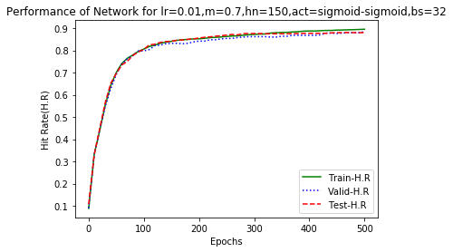

```python
epoch = range(0,501,10)
plt.plot(epoch, Run12_thr, color='g',linestyle='-',label='Train-H.R')
plt.plot(epoch, Run12_vhr, color='blue' ,linestyle='dotted',label='Valid-H.R')
plt.plot(epoch, Run12_tehr, color='red',linestyle='dashed',label='Test-H.R')
plt.xlabel('Epochs')
plt.ylabel('Hit Rate(H.R)')
plt.legend()
plt.title('Performance of Network for lr=0.01,m=0.7,hn=150,act=sigmoid-sigmoid,bs=32')
plt.show()
```

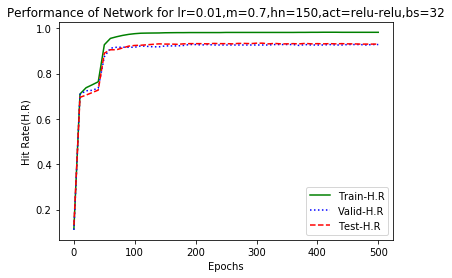

```python
epoch = range(0,501,10)
plt.plot(epoch, Run13_thr, color='g',linestyle='-',label='Train-H.R')
plt.plot(epoch, Run13_vhr, color='blue' ,linestyle='dotted',label='Valid-H.R')
plt.plot(epoch, Run13_tehr, color='red',linestyle='dashed',label='Test-H.R')
plt.xlabel('Epochs')
plt.ylabel('Hit Rate(H.R)')
plt.legend()
plt.title('Performance of Network for lr=0.01,m=0.7,hn=150,act=relu-relu,bs=32')
plt.show()
```

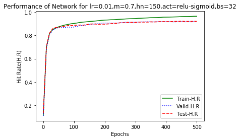

```python
epoch = range(0,501,10)
plt.plot(epoch, Run14_thr, color='g',linestyle='-',label='Train-H.R')
plt.plot(epoch, Run14_vhr, color='blue' ,linestyle='dotted',label='Valid-H.R')
plt.plot(epoch, Run14_tehr, color='red',linestyle='dashed',label='Test-H.R')
plt.xlabel('Epochs')
plt.ylabel('Hit Rate(H.R)')
plt.legend()
plt.title('Performance of Network for lr=0.01,m=0.7,hn=150,act=relu-sigmoid,bs=32')
plt.show()
```

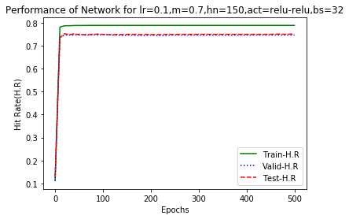

```python
epoch = range(0,501,10)
plt.plot(epoch, Run15_thr, color='g',linestyle='-',label='Train-H.R')
plt.plot(epoch, Run15_vhr, color='blue' ,linestyle='dotted',label='Valid-H.R')
plt.plot(epoch, Run15_tehr, color='red',linestyle='dashed',label='Test-H.R')
plt.xlabel('Epochs')
plt.ylabel('Hit Rate(H.R)')
plt.legend()
plt.title('Performance of Network for lr=0.1,m=0.7,hn=150,act=relu-relu,bs=32')
plt.show()
```

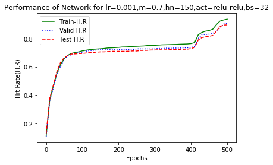

```python
epoch = range(0,501,10)
plt.plot(epoch, Run16_thr, color='g',linestyle='-',label='Train-H.R')
plt.plot(epoch, Run16_vhr, color='blue' ,linestyle='dotted',label='Valid-H.R')
plt.plot(epoch, Run16_tehr, color='red',linestyle='dashed',label='Test-H.R')
plt.xlabel('Epochs')
plt.ylabel('Hit Rate(H.R)')
plt.legend()
plt.title('Performance of Network for lr=0.001,m=0.7,hn=150,act=relu-relu,bs=32')
plt.show()
```

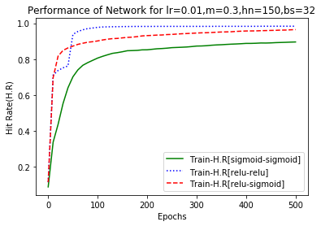

```python
epoch = range(0,501,10)
plt.plot(epoch, Run9_thr, color='g',linestyle='-',label='Train-H.R[sigmoid-sigmoid]')
plt.plot(epoch, Run10_thr, color='blue' ,linestyle='dotted',label='Train-H.R[relu-relu]')
plt.plot(epoch, Run11_thr, color='red',linestyle='dashed',label='Train-H.R[relu-sigmoid]')
plt.xlabel('Epochs')
plt.ylabel('Hit Rate(H.R)')
plt.legend()
plt.title('Performance of Network for lr=0.01,m=0.3,hn=150,bs=32')
plt.show()
```

[figure not shown]

```python
epoch = range(0,501,10)
plt.plot(epoch, Run14_thr, color='g',linestyle='-',label='Train-H.R[lr=0.01]')
plt.plot(epoch, Run15_thr, color='red',linestyle='dashed',label='Train-H.R[lr=0.1]')
plt.plot(epoch, Run16_thr, color='blue',linestyle='dotted',label='Train-H.R[lr=0.001]')

plt.xlabel('Epochs')
plt.ylabel('Hit Rate(H.R)')
plt.legend()
plt.title('Performance of Network for m=0.7, act=relu-relu, hn=150, bs=32')
plt.show()
```

```python
Run1_tec=[x / 1000 for x in Run1['tec']]
Run1_tc=[x / 3500 for x in Run1['tc']]
Run1_vc=[x / 500 for x in Run1['vc']]
Run2_tec=[x / 1000 for x in Run2['tec']]
Run2_tc=[x / 3500 for x in Run2['tc']]
Run2_vc=[x / 500 for x in Run2['vc']]
Run3_tec=[x / 1000 for x in Run3['tec']]
Run3_tc=[x / 3500 for x in Run3['tc']]
Run3_vc=[x / 500 for x in Run3['vc']]
Run4_tec=[x / 1000 for x in Run4['tec']]
Run4_tc=[x / 3500 for x in Run4['tc']]
Run4_vc=[x / 500 for x in Run4['vc']]
Run5_tec=[x / 1000 for x in Run5['tec']]
Run5_tc=[x / 3500 for x in Run5['tc']]
Run5_vc=[x / 500 for x in Run5['vc']]
Run6_tec=[x / 1000 for x in Run6['tec']]
Run6_tc=[x / 3500 for x in Run6['tc']]
Run6_vc=[x / 500 for x in Run6['vc']]
Run7_tec=[x / 1000 for x in Run7['tec']]
Run7_tc=[x / 3500 for x in Run7['tc']]
Run7_vc=[x / 500 for x in Run7['vc']]
Run8_tec=[x / 1000 for x in Run8['tec']]
Run8_tc=[x / 3500 for x in Run8['tc']]
Run8_vc=[x / 500 for x in Run8['vc']]
```